# Red Wine Quality Exploration by Nan Li

# Bivariate Plots Section

### Correlation plot

```
##                      fixed.acidity volatile.acidity citric.acid
## fixed.acidity           1.00000000     -0.256130895  0.67170343
## volatile.acidity       -0.25613089      1.000000000 -0.55249568
## citric.acid             0.67170343     -0.552495685  1.00000000
## residual.sugar          0.11477672      0.001917882  0.14357716
## chlorides               0.09370519      0.061297772  0.20382291
## free.sulfur.dioxide    -0.15379419     -0.010503827 -0.06097813
## total.sulfur.dioxide   -0.11318144      0.076470005  0.03553302
## density                 0.66804729      0.022026232  0.36494718
## pH                     -0.68297819      0.234937294 -0.54190414
## sulphates               0.18300566     -0.260986685  0.31277004
## alcohol                -0.06166827     -0.202288027  0.10990325
## quality                 0.12405165     -0.390557780  0.22637251
##                      residual.sugar    chlorides free.sulfur.dioxide
## fixed.acidity           0.114776724  0.093705186        -0.153794193
## volatile.acidity        0.001917882  0.061297772        -0.010503827
## citric.acid             0.143577162  0.203822914        -0.060978129
## residual.sugar          1.000000000  0.055609535         0.187048995
## chlorides               0.055609535  1.000000000         0.005562147
## free.sulfur.dioxide     0.187048995  0.005562147         1.000000000
## total.sulfur.dioxide    0.203027882  0.047400468         0.667666450
## density                 0.355283371  0.200632327        -0.021945831
## pH                     -0.085652422 -0.265026131         0.070377499
## sulphates               0.005527121  0.371260481         0.051657572
## alcohol                 0.042075437 -0.221140545        -0.069408354
## quality                 0.013731637 -0.128906560        -0.050656057
##                      total.sulfur.dioxide     density          pH
## fixed.acidity                 -0.11318144  0.66804729 -0.68297819
## volatile.acidity               0.07647000  0.02202623  0.23493729
## citric.acid                    0.03553302  0.36494718 -0.54190414
## residual.sugar                 0.20302788  0.35528337 -0.08565242
## chlorides                      0.04740047  0.20063233 -0.26502613
## free.sulfur.dioxide            0.66766645 -0.02194583  0.07037750
## total.sulfur.dioxide           1.00000000  0.07126948 -0.06649456
## density                        0.07126948  1.00000000 -0.34169933
## pH                            -0.06649456 -0.34169933  1.00000000
## sulphates                      0.04294684  0.14850641 -0.19664760
## alcohol                       -0.20565394 -0.49617977  0.20563251
## quality                       -0.18510029 -0.17491923 -0.05773139
##                         sulphates     alcohol     quality
## fixed.acidity         0.183005664 -0.06166827  0.12405165
## volatile.acidity     -0.260986685 -0.20228803 -0.39055778
## citric.acid           0.312770044  0.10990325  0.22637251
## residual.sugar        0.005527121  0.04207544  0.01373164
## chlorides             0.371260481 -0.22114054 -0.12890656
## free.sulfur.dioxide   0.051657572 -0.06940835 -0.05065606
## total.sulfur.dioxide  0.042946836 -0.20565394 -0.18510029
## density               0.148506412 -0.49617977 -0.17491923
## pH                   -0.196647602  0.20563251 -0.05773139
## sulphates             1.000000000  0.09359475  0.25139708
## alcohol               0.093594750  1.00000000  0.47616632
## quality               0.251397079  0.47616632  1.00000000
```

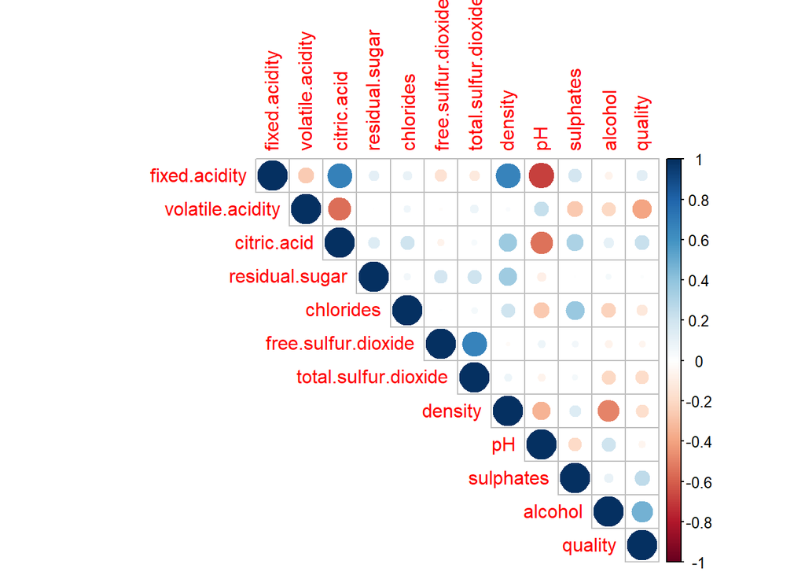

Top 4 correlation coefficients with quality are:

alcohol = 0.4762, volatile.acidity = -0.3906, sulphates = 0.2514, citric.acid = 0.2263.

The quality does not strongly correlate with any other variables. The highest correlation coefficient is 0.4762 with alcohol. So the alcohol content can decide the quality. On the other hand, the more volatile.acidity, the worse quality.

Top 4 correlation coefficients in datas are:

fixed.acidity with pH = -0.6830, fixed.acidity with citric.acid = 0.6717, fixed.acidity with density = 0.6680, total.sulfur.dioxide with free.sulfur.dioxide = 0.6677.

In addition, since total.sulfur.dioxide is including free.sulfur.dioxide, they tend to correlate with each other. And fixed.acidity has a negitive coefficient with PH due to the acid. Consider the figures below.

### Fixed.acidity vs. PH

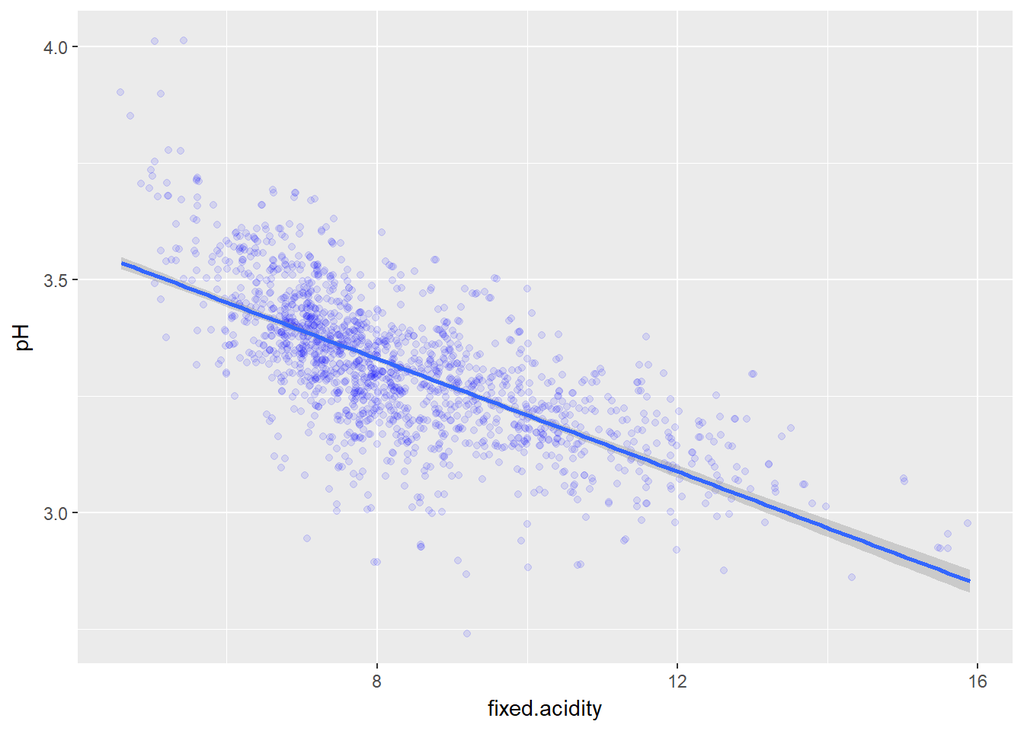

### Fixed.acidity vs. Citric.acid

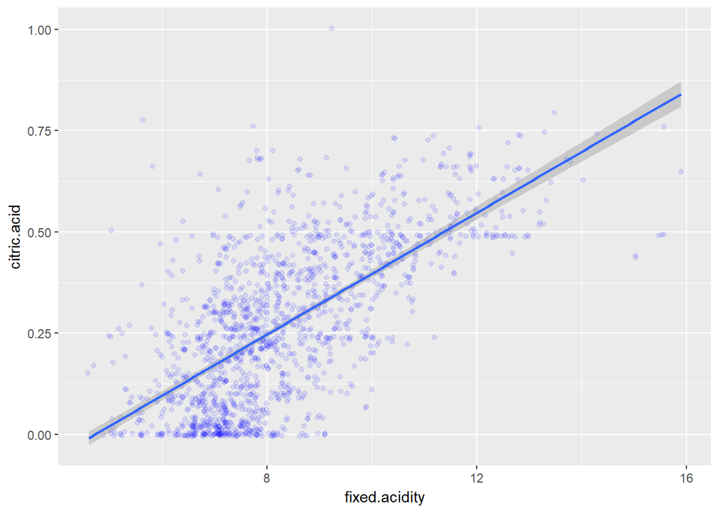

### Fixed.acidity vs. Density

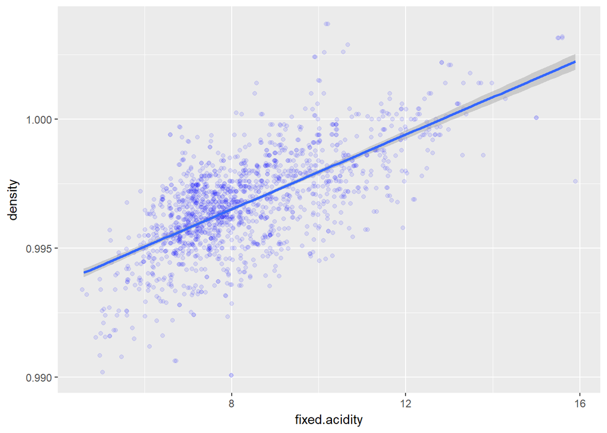

### Total.sulful.dioxide vs. Free.sulfur.dioxide

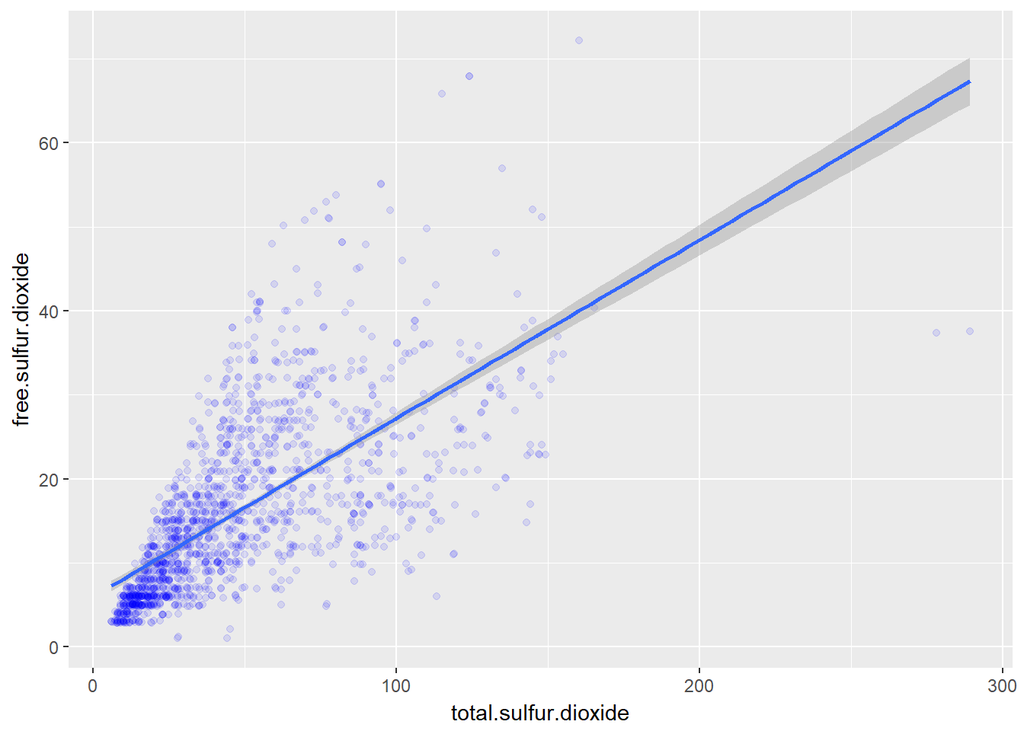

### Alcohol vs. Quality boxplot

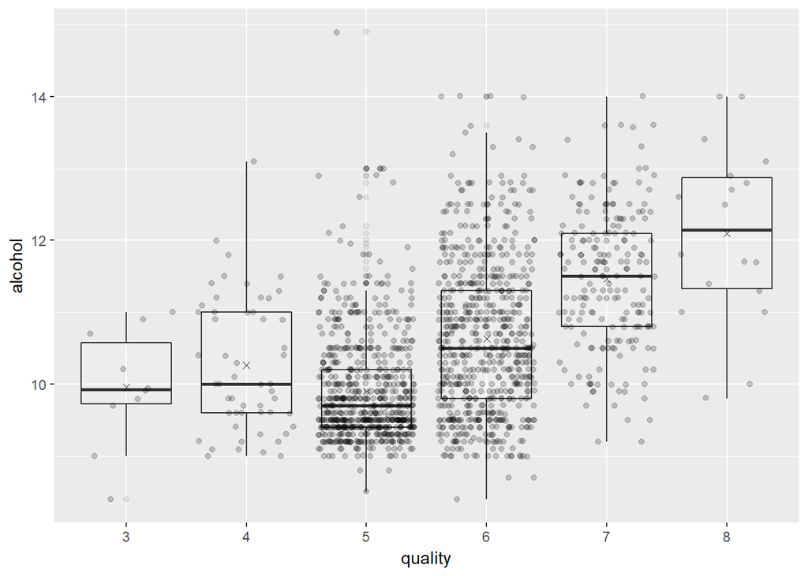

```
## rw$quality: 3
##    Min. 1st Qu.  Median    Mean 3rd Qu.    Max.
##   8.400   9.725   9.925   9.955  10.575  11.000
## --------------------------------------------------------
## rw$quality: 4
##    Min. 1st Qu.  Median    Mean 3rd Qu.    Max.
##    9.00    9.60   10.00   10.27   11.00   13.10
## --------------------------------------------------------
## rw$quality: 5
##    Min. 1st Qu.  Median    Mean 3rd Qu.    Max.
##     8.5     9.4     9.7     9.9    10.2    14.9
## --------------------------------------------------------
## rw$quality: 6
##    Min. 1st Qu.  Median    Mean 3rd Qu.    Max.
##    8.40    9.80   10.50   10.63   11.30   14.00
## --------------------------------------------------------
## rw$quality: 7
##    Min. 1st Qu.  Median    Mean 3rd Qu.    Max.
##    9.20   10.80   11.50   11.47   12.10   14.00
## --------------------------------------------------------
## rw$quality: 8
##    Min. 1st Qu.  Median    Mean 3rd Qu.    Max.
##    9.80   11.32   12.15   12.09   12.88   14.00
```

The boxplot shows the higher quality red wine has more alcohol content.

### Sulphates vs. Quality

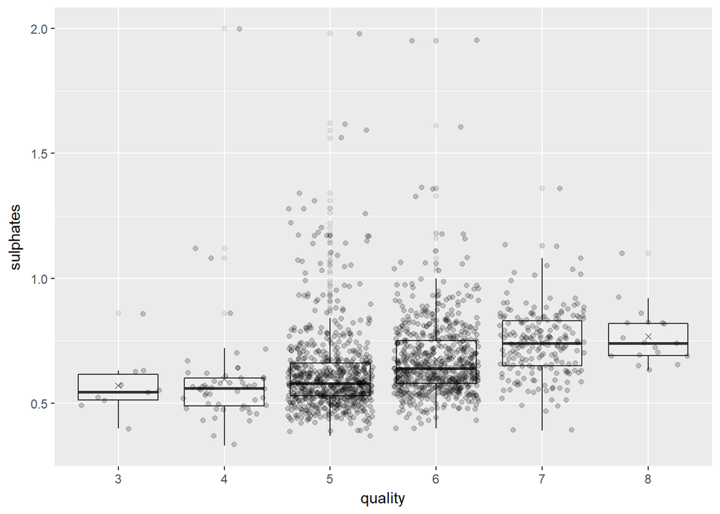

```
## rw$quality: 3
##    Min. 1st Qu.  Median    Mean 3rd Qu.    Max.
##  0.4000  0.5125  0.5450  0.5700  0.6150  0.8600
## --------------------------------------------------------
## rw$quality: 4
##    Min. 1st Qu.  Median    Mean 3rd Qu.    Max.
##  0.3300  0.4900  0.5600  0.5964  0.6000  2.0000
## --------------------------------------------------------
## rw$quality: 5
##    Min. 1st Qu.  Median    Mean 3rd Qu.    Max.
##   0.370   0.530   0.580   0.621   0.660   1.980
## --------------------------------------------------------
## rw$quality: 6
##    Min. 1st Qu.  Median    Mean 3rd Qu.    Max.
##  0.4000  0.5800  0.6400  0.6753  0.7500  1.9500
## --------------------------------------------------------
## rw$quality: 7
##    Min. 1st Qu.  Median    Mean 3rd Qu.    Max.
##  0.3900  0.6500  0.7400  0.7413  0.8300  1.3600
## --------------------------------------------------------
## rw$quality: 8
##    Min. 1st Qu.  Median    Mean 3rd Qu.    Max.
##  0.6300  0.6900  0.7400  0.7678  0.8200  1.1000
```

# Bivariate Analysis

### Talk about some of the relationships you observed in this part of the investigation. How did the feature(s) of interest vary with other features in the dataset?

The sulphate and alcohol contents are very important for the quality of redwine, expecially higher quality levels such as 7 and 8.

### Did you observe any interesting relationships between the other features (not the main feature(s) of interest)?

For other features, it looks like fixed.acidity strongly correlated with some features. It negatively correlated with pH because the acid leads to a lower pH. And it also positive correlated with citric.acid and density.

### What was the strongest relationship you found?

The strongest relationship was between fixed.acidity and pH, which had a correlation coefficient of -0.6830.

# Multivariate Plots Section

### Sulphats vs. Alcohol for different qualities

[figure not shown]

The higher quality red wine is tend to sit on the top right of the plot.

### Sulphates vs. Density for different qualities

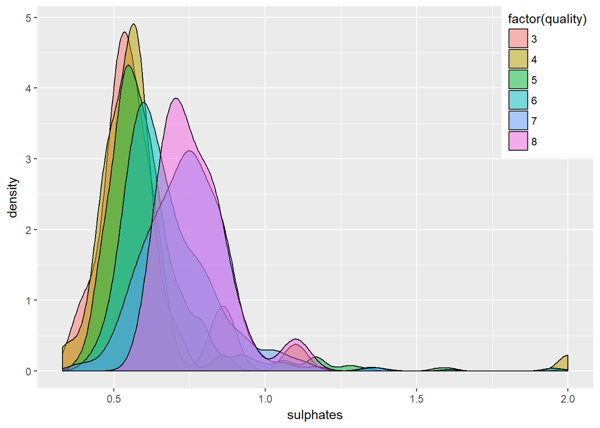

### Linear Model Analysis

```
##
## Calls:
## m1: lm(formula = as.numeric(quality) ~ alcohol, data = rw)
## m2: lm(formula = as.numeric(quality) ~ alcohol + sulphates, data = rw)
## m3: lm(formula = as.numeric(quality) ~ alcohol + sulphates + volatile.acidity,
##     data = rw)
## m4: lm(formula = as.numeric(quality) ~ alcohol + sulphates + volatile.acidity +
##     citric.acid, data = rw)
##
## ============================================================================
##                          m1            m2            m3            m4
## ----------------------------------------------------------------------------
##   (Intercept)          -0.125        -0.625***      0.611**       0.646**
##                        (0.175)       (0.177)       (0.196)       (0.201)
##   alcohol               0.361***      0.346***      0.309***      0.309***
##                        (0.017)       (0.016)       (0.016)       (0.016)
##   sulphates                           0.994***      0.679***      0.696***
##                                      (0.102)       (0.101)       (0.103)
##   volatile.acidity                                 -1.221***     -1.265***
##                                                    (0.097)       (0.113)
##   citric.acid                                                    -0.079
##                                                                  (0.104)
## ----------------------------------------------------------------------------
##   R-squared             0.227         0.270         0.336         0.336
##   adj. R-squared        0.226         0.269         0.335         0.334
##   sigma                 0.710         0.690         0.659         0.659
##   F                   468.267       294.988       268.912       201.777
##   p                     0.000         0.000         0.000         0.000
##   Log-likelihood    -1721.057     -1675.142     -1599.384     -1599.093
##   Deviance            805.870       760.894       692.105       691.852
##   AIC                3448.114      3358.284      3208.768      3210.186
##   BIC                3464.245      3379.793      3235.654      3242.448
##   N                  1599          1599          1599          1599
## ============================================================================
```

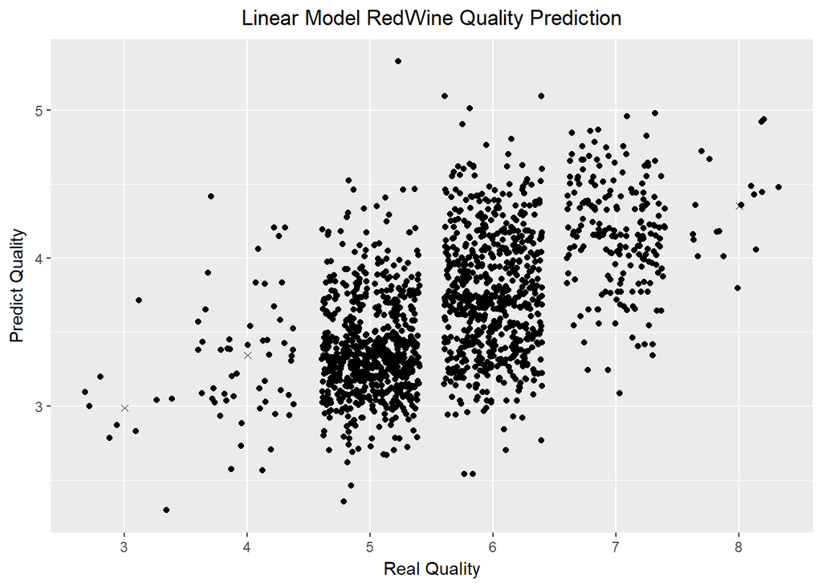

# Multivariate Analysis

### Talk about some of the relationships you observed in this part of the investigation. Were there features that strengthened each other in terms of looking at your feature(s) of interest?

Based on the graphs, the quality mainly related alcohol content and sulphates. But it looked like the largest density is in the quality 3 or 4 of red wine.

### Were there any interesting or surprising interactions between features?

The linear model is created among four major variables. Alcohol, sulphates, volatile.acidity and citric.acid. The coefficient of volatile.acidity is -1.265 which negatively effect the quality.

### OPTIONAL: Did you create any models with your dataset? Discuss the strengths and limitations of your model.

Yes. From the figure above, I can tell the predicition of linear model is lower than the real quality. But the predicition quality 3 is much better. For future work, I will try other models and compare with linear.

# Final Plots and Summary

### Plot One

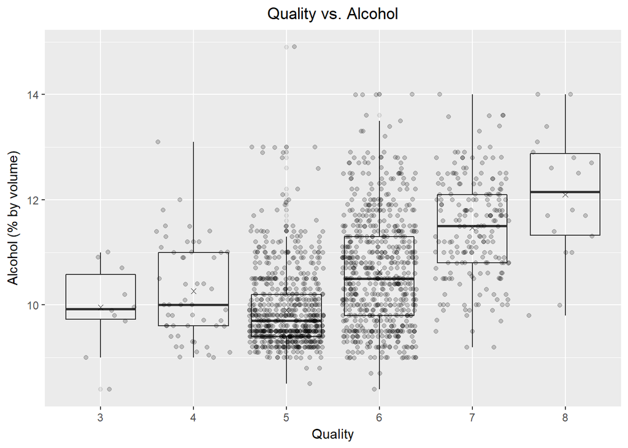

### Description One

It shows the best redwine has a highest alcohol content. So when we find some higher alcohol content in the redwine, it deserves to be paied.

### Plot Two

[figure not shown]

### Description Two

The trend of this figure is the higher quality is on the top right and the lower quality is on the bottom left. It’s easy to conclude the alcohol and sulphates are positively correlated with quality.

### Plot Three

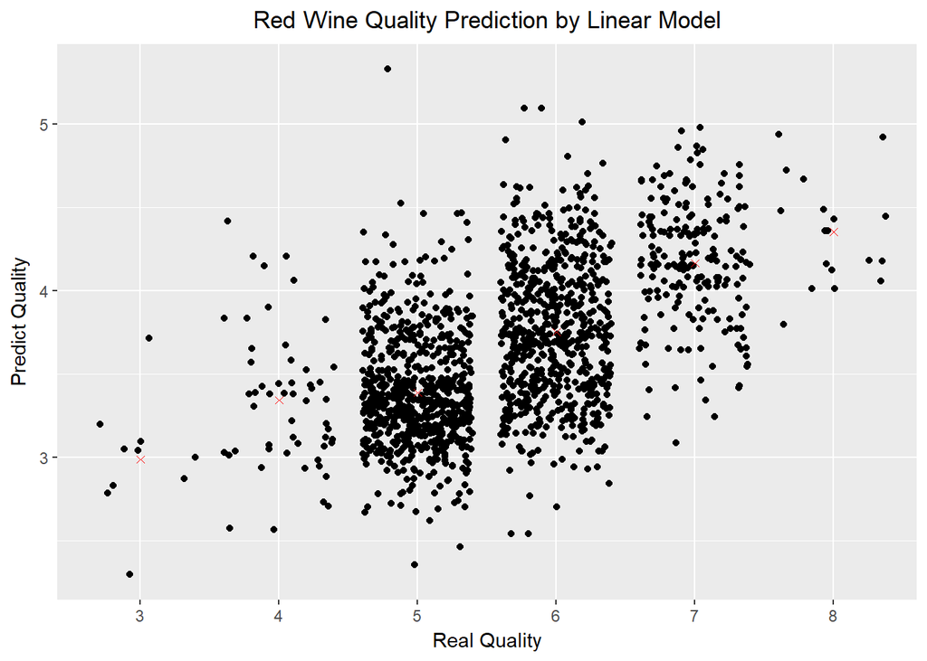

### Description Three

The prediction of the quality by linear model is obviously smaller than the real quality. It reflects the linear model is not suitable for this dataset. ——

# Reflection

The red wine quality dataset contains 1599 red wines with 11 variables on the chemical properties of the wine. In order to explore the chemical properties influence the quality, I tried to describe one variable, two variables and multiple variables by drawing the plots. Such as the volatile acidity negatively correlated to quality. A large amount of volatile acidity can lead to an unpleasant vinegar taste. However, the citric acid and sulphates can improve the quality since citric acid can add ‘freshness’ and flavor to wines and sulphates can contribute to sulfur dioxide gas levels. I also created a linear model and tried to predict the quality. The predict quality is lower than the real quality.

For data exploration, I’m thinking whether the number of dataset is a little bit small and it is not fair enough since only three experts graded the red wine. Maybe we can find 10 more experts to evaluate the red wine.

From the beginning to the end, I created so many plots. It is hard to tell which one is representative. So I wrote some comments after each plot and it will make easier to decide which one I should put in the conclusion.

For future work, I will try other model to predict the quality and compare with the linear model.